# Support Vector Machine

### ISLP Ch 9

### Dan Schumacher

#### Imports

```python
import ISLP
import numpy as np
import seaborn as sns
import matplotlib.pyplot as plt
import warnings
from sklearn.svm import SVC
from sklearn.model_selection import train_test_split, GridSearchCV
from sklearn.preprocessing import StandardScaler
from sklearn.metrics import classification_report, confusion_matrix
import pandas as pd
import matplotlib.pyplot as plt
from ISLP.svm import plot as plot_svm
from sklearn.linear_model import LogisticRegression
```

## 5. We have seen that we can fit an SVM with a non-linear kernel in order to perform classification using a non-linear decision boundary. We will now see that we can also obtain a non-linear decision boundary by performing logistic regression using non-linear transformations of the features.

#### (a) Generate a data set with n = 500 and p = 2, such that the observations belong to two classes with a quadratic decision boundary between them. For instance, you can do this as follows: rng = np.random.default_rng(5) x1 = rng.uniform(size=500) - 0.5 x2 = rng.uniform(size=500) - 0.5 y = x1**2 - x2**2 > 0

```python
# Seed for reproducibility
np.random.seed(27)

# Generate x1 and x2
x1 = np.random.uniform(size=500) - 0.5
x2 = np.random.uniform(size=500) - 0.5

# Generate labels y based on the quadratic decision boundary
y = (x1**2 - x2**2 > 0).astype(int)
```

#### (b) Plot the observations, colored according to their class labels. Your plot should display X1 on the x-axis, and X2 on the yaxis.

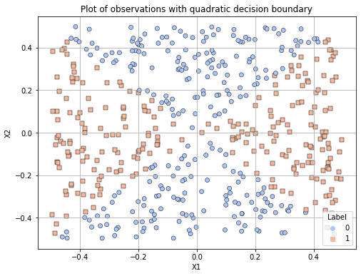

```python
# Seed for reproducibility
np.random.seed(11)

# Generate x1 and x2
x1 = np.random.uniform(size=500) - 0.5
x2 = np.random.uniform(size=500) - 0.5

# Generate labels y based on the quadratic decision boundary
y = (x1**2 - x2**2 > 0).astype(int)

# Create a DataFrame for easier plotting with Seaborn
data = pd.DataFrame({'X1': x1, 'X2': x2, 'Label': y})

# Create the plot using Seaborn
plt.figure(figsize=(8, 6))
sns.scatterplot(data=data, x='X1', y='X2', hue='Label', palette='coolwarm', style='Label', markers=['o', 's'], edgecolor='k')

# Labeling the axes
plt.xlabel('X1')
plt.ylabel('X2')
plt.title('Plot of observations with quadratic decision boundary')
plt.grid(True)

# Show the plot
plt.show()
```

#### (c) Fit a logistic regression model to the data, using X1 and X2 as predictors.

```python
model = LogisticRegression()
X = data[['X1', 'X2']]
Y = data['Label']
model.fit(X, Y)
```

```
LogisticRegression()
```

#### (d) Apply this model to the training data in order to obtain a predicted class label for each training observation. Plot the observations, colored according to the predicted class labels. The ecision boundary should be linear.

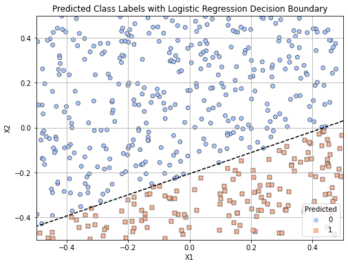

```python
# Predict class labels for the observations
predicted_labels = model.predict(X)

# Update the DataFrame to include the predicted labels
data['Predicted'] = predicted_labels

# Plotting the observations based on predicted class labels
plt.figure(figsize=(8, 6))
sns.scatterplot(data=data, x='X1', y='X2', hue='Predicted', palette='coolwarm', style='Predicted', markers=['o', 's'], edgecolor='k')

# Create a mesh grid for plotting decision boundary
xx, yy = np.meshgrid(np.linspace(-0.5, 0.5, 500), np.linspace(-0.5, 0.5, 500))
Z = model.predict(np.c_[xx.ravel(), yy.ravel()])
Z = Z.reshape(xx.shape)

# Plot the decision boundary
plt.contour(xx, yy, Z, levels=[0.5], linestyles=['dashed'], colors=['black'])

# Labeling and showing the plot
plt.xlabel('X1')
plt.ylabel('X2')
plt.title('Predicted Class Labels with Logistic Regression Decision Boundary')
plt.grid(True)
plt.show()
```

###### ------------------- this isn't what it asked for, but I think this is more useful. -------------------

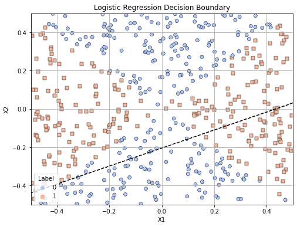

```python
warnings.filterwarnings(action='ignore', category=UserWarning, module='sklearn')

# Optional: Plotting the decision boundary
# Create a mesh grid
xx, yy = np.meshgrid(np.linspace(-0.5, 0.5, 500), np.linspace(-0.5, 0.5, 500))
Z = model.predict(np.c_[xx.ravel(), yy.ravel()])
Z = Z.reshape(xx.shape)

# Plot
plt.figure(figsize=(8, 6))
sns.scatterplot(data=data, x='X1', y='X2', hue='Label', palette='coolwarm', style='Label', markers=['o', 's'], edgecolor='k')
plt.contour(xx, yy, Z, levels=[0], linestyles=['dashed'], colors=['black'])
plt.xlabel('X1')
plt.ylabel('X2')
plt.title('Logistic Regression Decision Boundary')
plt.grid(True)
plt.show()
```

#### (e) Now fit a logistic regression model to the data using non-linear functions of X1 and X2 as predictors (e.g. X12, X1×X2, log(X2), nd so forth).

```python
from sklearn.linear_model import LogisticRegression

feature_dict = {
    'x1s': x1**2,
    'x2s': x2**2,
    'x1x2': x1*x2,
    'logx1': np.log(x1 + 0.5 + 1e-10), # Adding 0.5 to shift all values positive and a small epsilon to avoid log(0)
    'logx2': np.log(x2 + 0.5 + 1e-10)
}

X_non_lin = pd.DataFrame(feature_dict)
Y = data['Label']

model = LogisticRegression()
model.fit(X_non_lin, Y)
```

```
LogisticRegression()
```

#### (f) Apply this model to the training data in order to obtain a predicted class label for each training observation. Plot the observations, colored according to the predicted class labels. The ecision boundary should be obviously non-linear. If it is not, hen repeat (a)–(e) until you come up with an example in which he predicted class labels are obviously non-linear.

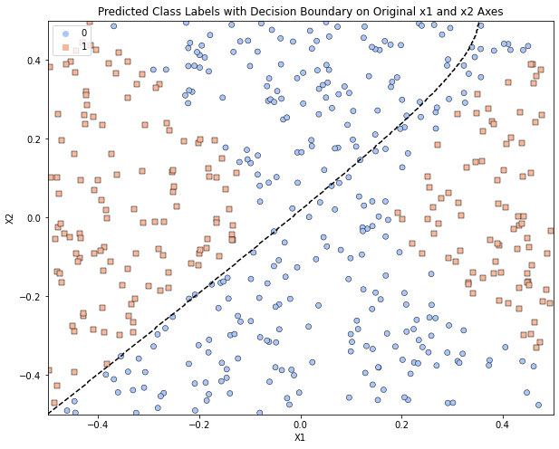

```python
import numpy as np
import matplotlib.pyplot as plt
import seaborn as sns
import pandas as pd
from sklearn.linear_model import LogisticRegression

# Predict the class labels for the original data
predicted_labels = model.predict(X_non_lin)

# Create a mesh grid for x1 and x2 directly
xx, yy = np.meshgrid(np.linspace(-0.5, 0.5, 500), np.linspace(-0.5, 0.5, 500))

# Transform this grid for prediction
grid = pd.DataFrame({
    'x1s': (xx.ravel() - 0.5)**2,
    'x2s': (yy.ravel() - 0.5)**2,
    'x1x2': (xx.ravel() - 0.5) * (yy.ravel() - 0.5),
    'logx1': np.log(xx.ravel() - 0.5 + 0.5 + 1 + 1e-10),
    'logx2': np.log(yy.ravel() - 0.5 + 0.5 + 1 +  1e-10)
})

Z = model.predict(grid).reshape(xx.shape)

# Plotting the predicted labels
plt.figure(figsize=(10, 8))
sns.scatterplot(x=x1, y=x2, hue=predicted_labels, style=predicted_labels, markers=['o', 's'], palette='coolwarm', edgecolor='k')
plt.contour(xx, yy, Z, levels=[0.5], linestyles=['dashed'], colors=['black'])
plt.title('Predicted Class Labels with Decision Boundary on Original x1 and x2 Axes')
plt.xlabel('X1')
plt.ylabel('X2')
plt.show()
```

#### (g) Fit a support vector classifier to the data with X1 and X2 as predictors. Obtain a class prediction for each training observation. Plot the observations, colored according to the predicted lass labels.

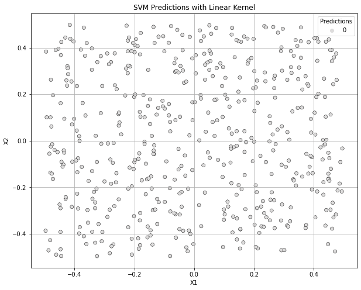

```python
import matplotlib.pyplot as plt
import seaborn as sns
from sklearn.svm import SVC

# Assuming X and Y have been defined and are available
svm = SVC(kernel='linear')
svm.fit(X, Y)
preds = svm.predict(X)

# Create a DataFrame for plotting
graph_me = X.copy()
graph_me['Predictions'] = preds  # Adding a new column for predicted labels

# Plotting
plt.figure(figsize=(10, 8))
sns.scatterplot(
    x='X1',
    y='X2',
    data=graph_me,
    hue='Predictions',  # Use this for coloring by predictions
    style='Predictions',  # Use this to vary markers by predictions
    palette='coolwarm',
#     markers=['o', 's'],
    edgecolor='k'
)
plt.title('SVM Predictions with Linear Kernel')
plt.xlabel('X1')
plt.ylabel('X2')
plt.grid(True)
plt.show()
```

- plotting w/ linear kernel only predicts 0s! not good.

#### (h) Fit a SVM using a non-linear kernel to the data. Obtain a class prediction for each training observation. Plot the observations, colored according to the predicted class labels.

##### Ploy Kernel

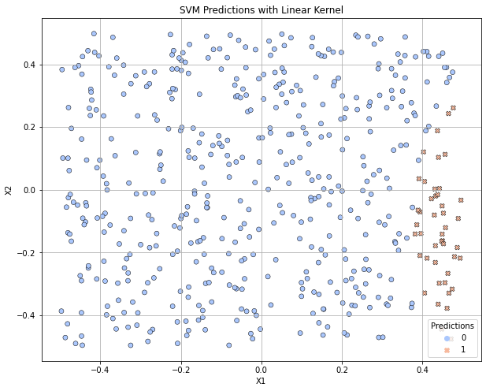

```python
import matplotlib.pyplot as plt
import seaborn as sns
from sklearn.svm import SVC

# Assuming X and Y have been defined and are available
svm = SVC(kernel='poly')
svm.fit(X, Y)
preds = svm.predict(X)

# Create a DataFrame for plotting
graph_me = X.copy()
graph_me['Predictions'] = preds  # Adding a new column for predicted labels

# Plotting
plt.figure(figsize=(10, 8))
sns.scatterplot(
    x='X1',
    y='X2',
    data=graph_me,
    hue='Predictions',  # Use this for coloring by predictions
    style='Predictions',  # Use this to vary markers by predictions
    palette='coolwarm',
#     markers=['o', 's'],
    edgecolor='k'
)
plt.title('SVM Predictions with Linear Kernel')
plt.xlabel('X1')
plt.ylabel('X2')
plt.grid(True)
plt.show()
```

- Now we are getting 2 classes, but still not good results

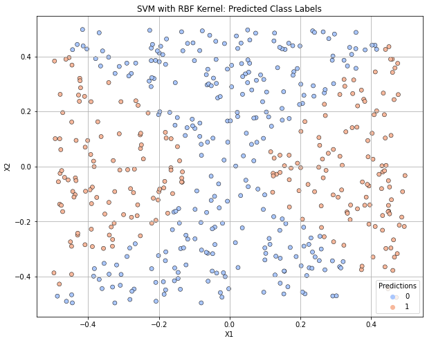

```python
import numpy as np
import pandas as pd
from sklearn.svm import SVC
from sklearn.preprocessing import StandardScaler
from sklearn.pipeline import make_pipeline

# Check class distribution

# Use a non-linear kernel with parameter tuning
# Scaling the features
svm_pipeline = make_pipeline(StandardScaler(), SVC(kernel='rbf', C=1.0, gamma='scale'))
svm_pipeline.fit(X, Y)

# Predict class labels
preds = svm_pipeline.predict(X)

# Update the DataFrame for plotting
graph_me['Predictions'] = preds

# Check the new distribution of predictions

# Plotting (the previous plotting code can be reused here)
plt.figure(figsize=(10, 8))
sns.scatterplot(
    x='X1',
    y='X2',
    data=graph_me,
    hue='Predictions',  # Color by the new predictions
    palette='coolwarm',
    edgecolor='k'
)
plt.title('SVM with RBF Kernel: Predicted Class Labels')
plt.xlabel('X1')
plt.ylabel('X2')
plt.grid(True)
plt.show()
```

#### (i) Comment on your results

- The RBF kernel gave the best predictions returning a shape that most closely refelects the classifications of the actual data.

## 8. In this problem, you will use support vector approaches in order to predict whether a given car gets high or low gas mileage based on the Auto data set.

#### (a) Create a binary variable that takes on a 1 for cars with gas mileage above the median, and a 0 for cars with gas mileage below the median.

```python
auto_df = ISLP.load_data('auto')
median_mpg = np.median(auto_df['mpg'])
auto_df['above_med_gas_mileage'] = [1 if x > median_mpg else 0 for x in auto_df['mpg']]
```

#### (b) Fit a support vector classifier to the data with various values of C, in order to predict whether a car gets high or low gas mileage. Report the cross-validation errors associated with different values of this parameter. Comment on your results. Note you will need to fit the classifier without the gas mileage variable to produce sensible results.

```python
X = auto_df.drop(['mpg', 'above_med_gas_mileage', 'name'], axis=1)  # predictor features
y = auto_df['above_med_gas_mileage']  # target

# Scale the features
scaler = StandardScaler()
X_scaled = scaler.fit_transform(X)

# Define the SVC model
svc = SVC()

# Setup parameter grid for both linear and non-linear kernels
param_grid = [
    {'kernel': ['linear'], 'C': [0.01, 0.1, 1, 10, 100]},

]

# Setup GridSearchCV
grid_search = GridSearchCV(svc, param_grid, cv=5, scoring='accuracy', verbose=0)

# Fit GridSearchCV
grid_search.fit(X_scaled, y)
print("Best parameters:", grid_search.best_params_)
print("Best cross-validation score: {:.2f}".format(grid_search.best_score_))

# Results from the grid search
results = pd.DataFrame(grid_search.cv_results_)
print(results[[ 'param_C', 'mean_test_score', 'std_test_score']])
```

```
Best parameters: {'C': 0.01, 'kernel': 'linear'}
Best cross-validation score: 0.90
  param_C  mean_test_score  std_test_score
0    0.01         0.900389        0.025223
1     0.1         0.875073        0.046895
2       1         0.852288        0.101522
3      10         0.857449        0.104920
4     100         0.857449        0.104920
```

- A 90% accuracy out of the box isn't bad at all! Maybe we can do better but still this is excellent for the first model

```python
# Splitting data into train and test sets for final evaluation
X_train, X_test, y_train, y_test = train_test_split(X_scaled, y, test_size=0.2, random_state=42)

# Using the best estimator directly
best_svc_linear = grid_search.best_estimator_
best_svc_linear.fit(X_train, y_train)

# Predict on test data
y_pred = best_svc_linear.predict(X_test)

# Print performance metrics
pd.DataFrame(confusion_matrix(y_test, y_pred))
```

|  | 0 | 1 |
| --- | --- | --- |
| 0 | 33 | 9 |
| 1 | 1 | 36 |

- Seems like we have identify false positives for most of our mistakes

```python
print(classification_report(y_test, y_pred))
```

```
              precision    recall  f1-score   support

           0       0.97      0.79      0.87        42
           1       0.80      0.97      0.88        37

    accuracy                           0.87        79
   macro avg       0.89      0.88      0.87        79
weighted avg       0.89      0.87      0.87        79
```

#### (c) Now repeat (b), this time using SVMs with radial and polynomial basis kernels, with different values of gamma and degree and C. Comment on your results.

```python
from sklearn.svm import SVC
from sklearn.model_selection import GridSearchCV
from sklearn.preprocessing import StandardScaler
from sklearn.metrics import classification_report, confusion_matrix

# Scaling the features
scaler = StandardScaler()
X_scaled = scaler.fit_transform(X)

# Define the SVC model
svc = SVC()

# Setup parameter grid
# Note: 'gamma' can be a scale which is 1/(n_features * X.var()) as 'auto',
# 'scale' which is 1/n_features as default, or a float value.
param_grid = [
    {'kernel': ['rbf'], 'C': [0.1, 1, 10, 100], 'gamma': [0.01, 0.1, 1, 'scale']},
    {'kernel': ['poly'], 'C': [0.1, 1, 10, 100], 'gamma': [0.01, 0.1, 1, 'scale'], 'degree': [2, 3, 4]}
]

# Setup GridSearchCV
grid_search = GridSearchCV(svc, param_grid, cv=5, scoring='accuracy', verbose=0)

# Fit GridSearchCV
grid_search.fit(X_scaled, y)

# Fit GridSearchCV
grid_search.fit(X_scaled, y)
print("Best parameters:", grid_search.best_params_)
print("Best cross-validation score: {:.2f}".format(grid_search.best_score_))
```

```
Best parameters: {'C': 0.1, 'gamma': 1, 'kernel': 'rbf'}
Best cross-validation score: 0.91
```

- This improved results by 1% Whoop!

```python
# Using the best estimator directly
best_svc_rbf_poly = grid_search.best_estimator_
best_svc_rbf_poly.fit(X_train, y_train)

# Predict on test data
y_pred = best_svc_rbf_poly.predict(X_test)

# Print performance metrics
pd.DataFrame(confusion_matrix(y_test, y_pred))
```

|  | 0 | 1 |
| --- | --- | --- |
| 0 | 32 | 10 |
| 1 | 0 | 37 |

- We still have 10 mistakes though, so Idk why it is showing our accuracy went up. Our single false neg transferred to a false pos.

```python
print(classification_report(y_test, y_pred))
```

```
              precision    recall  f1-score   support

           0       1.00      0.76      0.86        42
           1       0.79      1.00      0.88        37

    accuracy                           0.87        79
   macro avg       0.89      0.88      0.87        79
weighted avg       0.90      0.87      0.87        79
```

#### (d) Make some plots to back up your assertions in (b) and (c). Hint: In the lab, we used the plot_svm() function for fitted SVMs. When p > 2, you can use the keyword argument features to create plots displaying pairs of variables at a time.

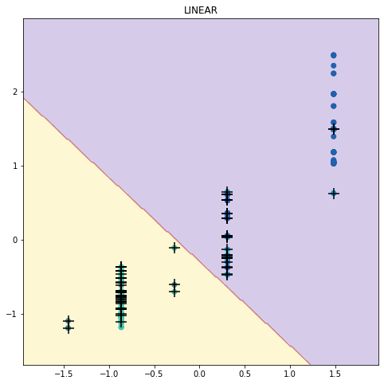

```python
# Visualization of decision boundaries - Adjust this if needed for feature dimensions
fig, ax = plt.subplots(figsize=(8, 8))

plot_svm(X_train, y_train, best_svc_linear, ax=ax)
plt.title('LINEAR')
plt.show()
```

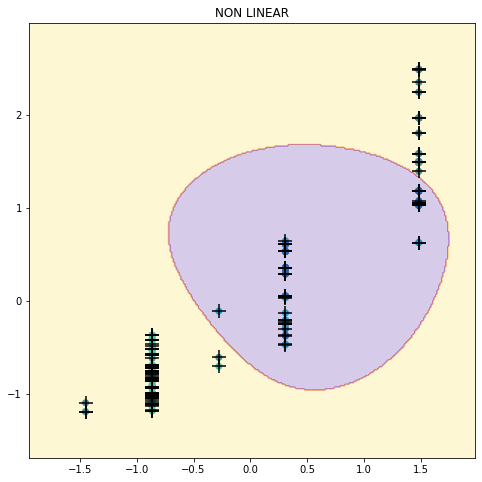

```python
# Visualization of decision boundaries - Adjust this if needed for feature dimensions
fig, ax = plt.subplots(figsize=(8, 8))

plot_svm(X_train, y_train, best_svc_rbf_poly, ax=ax)
plt.title('NON LINEAR')
plt.show()
```

## 9. This problem involves the OJ data set which is part of the ISLP package.

```python
oj_df = ISLP.load_data('OJ')
```

```python
oj_df['Store7'] = np.where(oj_df['Store7'] == 'Yes',1,0)
```

#### (a) Create a training set containing a random sample of 800 observations, and a test set containing the remaining observations.

```python
train, test = train_test_split(oj_df, test_size=len(oj_df) - 800, random_state=27)
```

```python
X_train = train.drop('Purchase', axis=1)
y_train = train['Purchase']

X_test = test.drop('Purchase', axis=1)
y_test = test['Purchase']
```

#### (b) Fit a support vector classifier to the training data using C = 0.01, with Purchase as the response and the other variables as predictors. How many support points are there?

```python
# Fit the SVC model
svc_model = SVC(C=0.01, kernel='linear')
svc_model.fit(X_train, y_train)

# Extract support vectors
support_vectors = svc_model.support_vectors_
print(f"Number of support vectors: {len(svc_model.support_)}")

# Detailed breakdown of support vectors per class
print(f"Support vectors per class: {svc_model.n_support_}")
```

```
Number of support vectors: 634
Support vectors per class: [318 316]
```

#### (c) What are the training and test error rates?

```python
from sklearn.metrics import accuracy_score

# Predict on the training data
y_train_pred = svc_model.predict(X_train)

# Calculate training accuracy and error rate
train_accuracy = accuracy_score(y_train, y_train_pred)
train_error_rate = 1 - train_accuracy

# Predict on the test data
y_test_pred = svc_model.predict(X_test)  # Assuming X_test is already defined and includes 'Purchase'

# Calculate test accuracy and error rate
test_accuracy = accuracy_score(y_test, y_test_pred)
test_error_rate = 1 - test_accuracy

print(f"Training Error Rate: {train_error_rate:.2f}")
print(f"Test Error Rate: {test_error_rate:.2f}")
```

```
Training Error Rate: 0.22
Test Error Rate: 0.19
```

#### (d) Use cross-validation to select an optimal C. Consider values in the range 0.01 to 10.

```python
param_grid = {'C': [0.01, 0.1, 1, 5, 10]}

# Setup the grid search with cross-validation
optim_c_svc = GridSearchCV(estimator=SVC(kernel='linear'), param_grid=param_grid, cv=5, scoring='accuracy')

# Fit the grid search to the data
optim_c_svc.fit(X_train, y_train)  # Changed from X_train_features to X_train

# Print out the best C value and cross-validation score
print(f"Best C value: {optim_c_svc.best_params_['C']}")
print(f"Best cross-validation score: {optim_c_svc.best_score_:.2f}")
```

```
Best C value: 10
Best cross-validation score: 0.82
```

#### (e) Compute the training and test error rates using this new value for C.

```python
# Predict on the test data
y_test_pred = optim_c_svc.predict(X_test)  # Assuming X_test is already defined and includes 'Purchase'

# Calculate test accuracy and error rate
test_accuracy = accuracy_score(y_test, y_test_pred)
test_error_rate = 1 - test_accuracy

print(f"Test Error Rate: {test_error_rate:.2f}")
```

```
Test Error Rate: 0.16
```

#### (f) Repeat parts (b) through (e) using a support vector machine with a radial kernel. Use the default value for gamma.

```python
from sklearn.svm import SVC
from sklearn.model_selection import train_test_split, GridSearchCV
from sklearn.metrics import accuracy_score

# Assuming all necessary imports are done and the data is already loaded and split into X_train, y_train, X_test, y_test

# Define the parameter range for C with an RBF kernel
param_grid = [
    {'kernel': ['rbf'], 'C': [0.1, 1, 10, 100]}
]

# Set up the grid search with cross-validation for an SVC with a radial kernel
dif_kernels = GridSearchCV(estimator=SVC(), param_grid=param_grid, cv=5, scoring='accuracy')

# Fit the grid search to the data
dif_kernels.fit(X_train, y_train)

# Print out the best parameters and cross-validation score
print(f"Best parameters: {dif_kernels.best_params_}")
print(f"Best cross-validation score: {dif_kernels.best_score_:.2f}")

# Using the best estimator to predict on test data
y_test_pred = dif_kernels.predict(X_test)

# Calculate test accuracy and error rate
test_accuracy = accuracy_score(y_test, y_test_pred)
test_error_rate = 1 - test_accuracy

print(f"Test Error Rate: {test_error_rate:.2f}")
```

```
Best parameters: {'C': 0.1, 'kernel': 'rbf'}
Best cross-validation score: 0.60
Test Error Rate: 0.37
```

#### (g) Repeat parts (b) through (e) using a support vector machine with a polynomial kernel. Set degree = 2.

```python
from sklearn.svm import SVC
from sklearn.model_selection import GridSearchCV, train_test_split
from sklearn.metrics import accuracy_score

# Assuming the data has already been preprocessed and split into X_train, y_train, X_test, y_test

# Define the parameter range for C with a polynomial kernel of degree 2
param_grid = {
    'kernel': ['poly'],
    'degree': [2],  # Polynomial degree
    'C': [0.1, 1, 10, 100]  # Range of C values to try
}

# Setup the grid search with cross-validation
poly_kernel_svc = GridSearchCV(estimator=SVC(), param_grid=param_grid, cv=5, scoring='accuracy')

# Fit the grid search to the data
poly_kernel_svc.fit(X_train, y_train)

# Print out the best parameters and cross-validation score
print(f"Best parameters: {poly_kernel_svc.best_params_}")
print(f"Best cross-validation score: {poly_kernel_svc.best_score_:.2f}")

# Using the best estimator to predict on test data
y_test_pred = poly_kernel_svc.predict(X_test)

# Calculate test accuracy and error rate
test_accuracy = accuracy_score(y_test, y_test_pred)
test_error_rate = 1 - test_accuracy

print(f"Test Error Rate: {test_error_rate:.2f}")
```

```
Best parameters: {'C': 0.1, 'degree': 2, 'kernel': 'poly'}
Best cross-validation score: 0.60
Test Error Rate: 0.37
```

#### (h) Overall, which approach seems to give the best results on this data

- Linear kernal with a C of 10 gave an 84% acc on the test data!.